```python
from IPython.core.display import HTML

def css_styling():
    styles = open("../styles/custom.css", "r").read()
    return HTML(styles)
css_styling()
```

# Example of an UWB channel Ray Tracing simulation

In the following, all steps required for going from the descrption of the radio scene until the calculation of the UWB channel impulse response is described on a simple example.

A ray-tracing simulation is controlled via a configuration file which is stored in the *ini* directory of the project directory. By default, a default configuration file named **default.ini** is loaded.

```python
from pylayers.simul.simulem import *
from pylayers.antprop.rays import *
from pylayers.antprop.channel import *
from pylayers.antprop.signature import *
from pylayers.measures.mesuwb import *
import pylayers.util.pyutil as pyu
import pylayers.signal.bsignal as bs
```

```
WARNING:traits.has_traits:DEPRECATED: traits.has_traits.wrapped_class, 'the 'implements' class advisor has been deprecated. Use the 'provides' class decorator.
```

A first step consists in loading a layout associated with the simulation. Here the `WHERE1.ini` layout is chosen along with the corresponding slabs and materials files `matDB.ini` and `slabDB.ini`.

This layout corresponds to the office building where the first WHERE1 UWB measurement campaign has been conducted.

The layout method loads those in a member layout object **L** of the simulation object **S**.

If not already available, the layout associated graphs are built.

```python
S = Simul()
# loading a layout
filestr = 'WHERE1'
S.layout(filestr+'.ini','matDB.ini','slabDB.ini')
try:
    S.L.dumpr()
except:
    S.L.build()
    S.L.dumpw()
```

```
new file WHERE1.str
```

The layout display is fully parameterized via the embedded **display** dictionnary member of the Layout object.which allows to configure the `showGs()` method behavior.

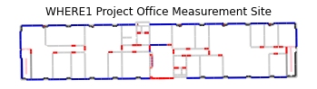

```python
S.L.display['ednodes']=False
S.L.display['nodes']=False
S.L.display['title']='WHERE1 Project Office Measurement Site'
S.L.display['overlay']=False
fig,ax=S.L.showGs()
```

## Adding coordinates of transmiting and receiving points

Coordinates of transmitters and receivers for the simulation are stored in **.ini** files. The transmitter and the receiver are instances of the class `RadioNode` which offers different methods for specifying nodes positions. The stucture of this **.ini** file presented below. The node Id is associated with the 3 coordinates $x,y,z$ separated by white spaces.

```
[coordinates]
1 = -12.2724 7.76319999993 1.2
2 = -18.7747 15.1779999998 1.2
3 = -4.14179999998 8.86029999983 1.2
4 = -9.09139999998 15.1899000001 1.2
```

```python
S.tx = RadioNode(_fileini='w2m1rx.ini',_fileant='defant.vsh3')
S.rx = RadioNode(_fileini='w2m1tx.ini',_fileant='defant.vsh3')
```

The whole simulation setup can then be displayed using the **show** method of the Simulation object

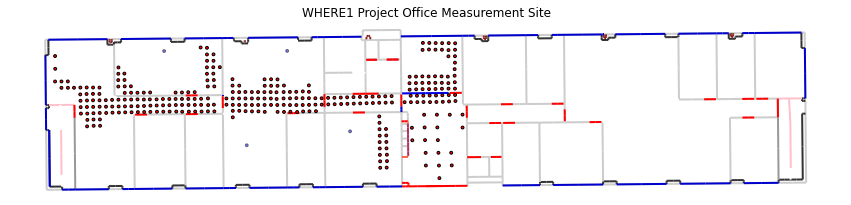

```python
fig = figure(figsize=(15,10))
fig,ax = S.show()
```

The different object of the simulation can be accessed to get different information. Below i.e the number of transmitter and receiver points.

```python
print 'number of Tx :',len(S.tx.points.keys())
print 'number of rx :',len(S.rx.points.keys())
```

```
number of Tx : 302
number of rx : 4
```

The decomposition of the layout in a set of disjoint cycles is represented below. Not all cycles are rooms.

```
(-40.0, 40.0, 2.0, 18.0)
```

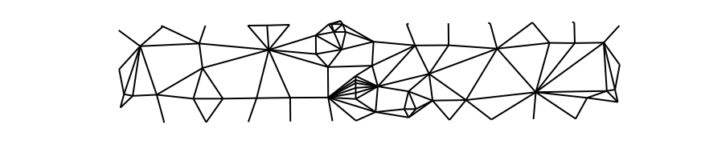

```python
fig =plt.figure(figsize=(15,10))
fig,ax=S.L.showG('t',fig=fig)
plt.axis('off')
```

```
(-40.0, 40.0, 2.0, 18.0)
```

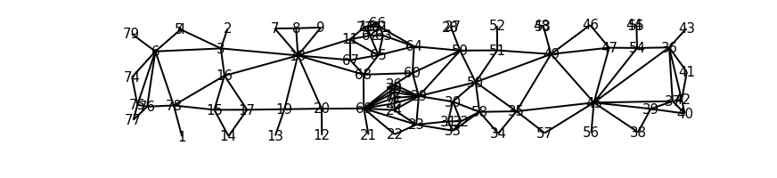

```python
fig,ax=S.L.showG('t',labels=True,figsize=(15,10))
plt.axis('off')
```

```python
istuple = filter(lambda x: type(eval(x))==tuple,S.L.Gi.node.keys())
cy5 = filter(lambda x: eval(x)[1]==5,istuple)
print cy5
```

[output not shown]

Then an existing interaction is picked up and the neighbors in the graph of interactions $\mathcal{G}_i$ are shown

```python
nx.neighbors(S.L.Gi,'(140, 5, 78)')
```

```
['(38, 78)',
 '(14, 78)',
 '(135, 78, 22)',
 '-253',
 '-250',
 '(32, 78, 76)',
 '(42, 78, 21)',
 '(36, 78)',
 '(37, 78)',
 '(36, 78, 2)',
 '(32, 78)',
 '(14, 78, 76)',
 '(38, 78, 2)',
 '(43, 78)',
 '(42, 78)']
```

Then a selected sequence of interactions is chosen and the attribute `output` of the corresponding edge is shown. The result is the set of possible next interactions. Notice that associated with each of these potential output interactions is associated a number $0<\alpha \le 1$ which indicates the probability of the corresponding sequence with respect of the full range of incidence angles. This value is not fully exploited yet in the algorithm which seek for [`Signatures`](http://pylayers.github.io/pylayers/modules/pylayers.antprop.signature.html)

```python
S.L.Gi.edge['(140, 5, 78)']['(38, 78)']
```

```
{'output': {'(135, 78, 22)': 0.35579843644453529,
  '(140, 78, 5)': 0.20141398602845637,
  '(42, 78)': 0.4427875775270072,
  '(42, 78, 21)': 0.4427875775270072}}
```

## Signatures, rays and propagation and transmission channel

```python
# Choose Tx and Rx coordinates
itx=10
irx=2
tx= S.tx.points[itx]
rx= S.rx.points[irx]
```

```python
tx
```

```
array([-24.867 ,  12.3097,   1.2   ])
```

```python
rx
```

```
array([-18.7747,  15.178 ,   1.2   ])
```

A signature is a sequence of layout objects (points and segments) which are involved in a given optical ray, relating the transmiter and the receiver. The signature is calculated from a layout cycle to an other layout cycle. This means that it is needed first to retrieve the cycle number from point coordinates. This is done thanks to the helping function [`pt2cy`](http://pylayers.github.io/pylayers/modules/generated/pylayers.gis.layout.Layout.pt2cy.html), point to cycle function.

```python
ctx=S.L.pt2cy(tx)
crx=S.L.pt2cy(rx)
print 'tx point belongs to cycle ',ctx
print 'rx point belongs to cycle ',crx
```

```
tx point belongs to cycle  5
rx point belongs to cycle  4
```

Then the signature between the 2 chosen cycles can be calculated. This is done by instantiating a Signature object with a given layout and the 2 cycle number.

The `__repr__` of a signature object provides information about the number of signatures for each number of interactions.

```python
Si = Signatures(S.L,ctx,crx)
```

```python
Si.run4(cutoff=4,algo='old')
```

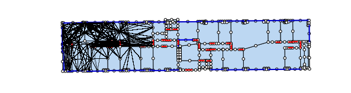

```python
Si.show(S.L,figsize=(10,10))
```

```python
#Si.run4(cutoff=5)
```

Once the signature has been obtained, 2D rays are calculated with the `rays()` method of the signature **Si**. The coordinates of a transmitter and a receiver should be parameters of the function. **r2d** object has a `show` and `show3` method.

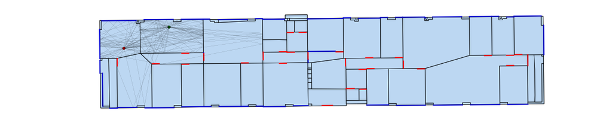

```python
figsize(20,20)
r2d = Si.rays(tx,rx)
S.L.display['ednodes']=False
r2d.show(S.L,figsize=(20,20),nodes=False)
```

```python
r2d
```

```
N2Drays : 42
from 24395 signatures
#Rays/#Sig: 0.00172166427547
pTx : [-24.867   12.3097   1.2   ]
pRx : [-18.7747  15.178    1.2   ]
1: [[12]]
2: [[ 12  12   5]
 [333 335  12]]
3: [[ 12  12  12   5   5   4  12  13]
 [335 335  30  12  12   5   5  12]
 [ 12  23 335 333 335  12  12  30]]
4: [[ 12  12  12   5   5 156  12   2]
 [335  30 335  12  15   5   5 330]
 [283 335 333 335  12  12  12  12]
 [335  12 342  12 335 333 335  30]]
5: [[ 12  12  12  12  12  12  12  13   5   5   5   5  15  12  12  12  12 330]
 [328  22  30 328 335  30 333   3  12  12 156 330   5   5   5  15   5  12]
 [339 339 335 335 283 335 334  13 335 335  12  12 330 331  12   5  12  30]
 [ 24 328 283  30 335 333 335  12 283 333 335 334  12   8 335  12  23  21]
 [328  24 335  12  12 342 328  30 335  11  23 335  30 342  12 335 335  30]]
6: [[140 140]
 [ 38  32]
 [135  37]
 [ 30 135]
 [333  30]
 [ 30 333]]
7: [[  5 330]
 [140 140]
 [135  38]
 [337 135]
 [ 46  30]
 [319 333]
 [335  30]]
```

```python
#r2d.show3(S.L)
```

Then, the **r2d** object is transformed into a 3D ray, taking into account the reflection on ceil and floor.

Once the 3D rays are obtained the local basis are determined with the specialized method [`to3D`](http://pylayers.github.io/pylayers/modules/generated/pylayers.antprop.rays.Rays.to3D.html)

```python
r3d=r2d.to3D(S.L)
```

The the local basis of each ray are determined with the specialized method [`locbas`](http://pylayers.github.io/pylayers/modules/generated/pylayers.antprop.rays.Rays.locbas.html)

```python
r3d.locbas(S.L)
```

and the the interaction matrices are filled with the sepcialized method [`fillinter`](http://pylayers.github.io/pylayers/modules/generated/pylayers.antprop.rays.Rays.fillinter.html)

```python
r3d.fillinter(S.L)
```

Below `ni` is the number of interactions

```python
r3d
```

```
Rays3D
----------
1 / 1 : [0]
2 / 5 : [1 2 3 4 5]
3 / 16 : [ 6  7  8  9 10 11 12 13 14 15 16 17 18 19 20 21]
4 / 30 : [22 23 24 25 26 27 28 29 30 31 32 33 34 35 36 37 38 39 40 41 42 43 44 45 46
 47 48 49 50 51]
5 / 50 : [ 52  53  54  55  56  57  58  59  60  61  62  63  64  65  66  67  68  69
  70  71  72  73  74  75  76  77  78  79  80  81  82  83  84  85  86  87
  88  89  90  91  92  93  94  95  96  97  98  99 100 101]
6 / 54 : [102 103 104 105 106 107 108 109 110 111 112 113 114 115 116 117 118 119
 120 121 122 123 124 125 126 127 128 129 130 131 132 133 134 135 136 137
 138 139 140 141 142 143 144 145 146 147 148 149 150 151 152 153 154 155]
7 / 42 : [156 157 158 159 160 161 162 163 164 165 166 167 168 169 170 171 172 173
 174 175 176 177 178 179 180 181 182 183 184 185 186 187 188 189 190 191
 192 193 194 195 196 197]
8 / 8 : [198 199 200 201 202 203 204 205]
9 / 4 : [206 207 208 209]
-----
ni : 1147
nl : 2504
```

## Calulating the Propagation Channel

The propagation channel is a [`Ctilde`](http://pylayers.github.io/pylayers/modules/pylayers.antprop.channel.html) object. This object can be evaluated for different frequency point thanks to the `eval()` method with a `fGHz` array as argument.

```python
S.fGHz
```

```
array([  2.  ,   2.05,   2.1 ,   2.15,   2.2 ,   2.25,   2.3 ,   2.35,
         2.4 ,   2.45,   2.5 ,   2.55,   2.6 ,   2.65,   2.7 ,   2.75,
         2.8 ,   2.85,   2.9 ,   2.95,   3.  ,   3.05,   3.1 ,   3.15,
         3.2 ,   3.25,   3.3 ,   3.35,   3.4 ,   3.45,   3.5 ,   3.55,
         3.6 ,   3.65,   3.7 ,   3.75,   3.8 ,   3.85,   3.9 ,   3.95,
         4.  ,   4.05,   4.1 ,   4.15,   4.2 ,   4.25,   4.3 ,   4.35,
         4.4 ,   4.45,   4.5 ,   4.55,   4.6 ,   4.65,   4.7 ,   4.75,
         4.8 ,   4.85,   4.9 ,   4.95,   5.  ,   5.05,   5.1 ,   5.15,
         5.2 ,   5.25,   5.3 ,   5.35,   5.4 ,   5.45,   5.5 ,   5.55,
         5.6 ,   5.65,   5.7 ,   5.75,   5.8 ,   5.85,   5.9 ,   5.95,
         6.  ,   6.05,   6.1 ,   6.15,   6.2 ,   6.25,   6.3 ,   6.35,
         6.4 ,   6.45,   6.5 ,   6.55,   6.6 ,   6.65,   6.7 ,   6.75,
         6.8 ,   6.85,   6.9 ,   6.95,   7.  ,   7.05,   7.1 ,   7.15,
         7.2 ,   7.25,   7.3 ,   7.35,   7.4 ,   7.45,   7.5 ,   7.55,
         7.6 ,   7.65,   7.7 ,   7.75,   7.8 ,   7.85,   7.9 ,   7.95,
         8.  ,   8.05,   8.1 ,   8.15,   8.2 ,   8.25,   8.3 ,   8.35,
         8.4 ,   8.45,   8.5 ,   8.55,   8.6 ,   8.65,   8.7 ,   8.75,
         8.8 ,   8.85,   8.9 ,   8.95,   9.  ,   9.05,   9.1 ,   9.15,
         9.2 ,   9.25,   9.3 ,   9.35,   9.4 ,   9.45,   9.5 ,   9.55,
         9.6 ,   9.65,   9.7 ,   9.75,   9.8 ,   9.85,   9.9 ,   9.95,
        10.  ,  10.05,  10.1 ,  10.15,  10.2 ,  10.25,  10.3 ,  10.35,
        10.4 ,  10.45,  10.5 ,  10.55,  10.6 ,  10.65,  10.7 ,  10.75,
        10.8 ,  10.85,  10.9 ,  10.95,  11.  ])
```

```python
Ct = r3d.eval(fGHz=S.fGHz)
```

```python
print "fmin : ",S.fGHz.min()
print "fmax : ",S.fGHz.max()
print "Nf : ", len(S.fGHz)
```

```
fmin :  2.0
fmax :  11.0
Nf :  181
```

The energy on each polarization couple of the channel can be obtained with the [`energy`](http://pylayers.github.io/pylayers/modules/generated/pylayers.antprop.channel.Ctilde.energy.html) method. By default this method scaling the channel with the Friis factor $\frac{c}{4\pi f}$.

```python
Ectt,Ecpp,Ectp,Ecpt = Ct.energy(Friis=True)
```

```python
Eco = Ectt+Ecpp
Ecross = Ectp+Ecpt
```

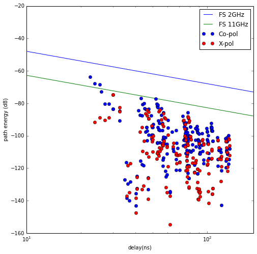

```python
tauns = arange(10,180,1)
PL2 = 32.4+20*log10(2)+20*log10(0.3*tauns)
PL11 = 32.4+20*log10(11)+20*log10(0.3*tauns)
fig = figure(figsize=(8,8))
plt.semilogx(tauns,-PL2)
plt.semilogx(tauns,-PL11)
plt.semilogx(Ct.tauk,10*np.log10(Eco),'ob')
plt.semilogx(Ct.tauk,10*np.log10(Ecross),'or')
plt.xlabel('delay(ns)')
plt.ylabel('path energy (dB)')
plt.legend(('FS 2GHz','FS 11GHz','Co-pol','X-pol'))
axis = plt.axis((0,180,-160,-20))
```

The multipath doa/dod diagram can be obtained via the method [`doadod`](http://pylayers.github.io/pylayers/modules/generated/pylayers.antprop.channel.Ctilde.doadod.html). The colorbar corresponds to the total energy of the path.

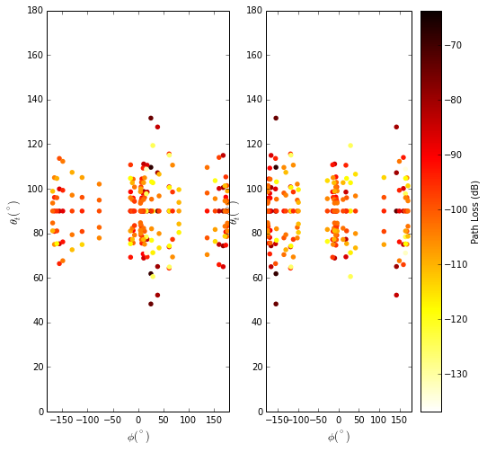

```python
fig = figure(figsize=(8,8))
Ct.doadod(phi=(-180,180),fig=fig)
```

```python
Ct.info()
```

```
Nfreq  : 181
Nray : 210
shape Ctt : (210, 181)
shape Ctp : (210, 181)
shape Cpt : (210, 181)
shape Cpp : (210, 181)
```

## Applying a waveform to the transmission channel

Once the propagation channel is obtained the transmission channel is calculated with the method [`prop2tran`](http://pylayers.github.io/pylayers/modules/generated/pylayers.antprop.channel.Ctilde.prop2tran.html). The Friis factor has to be set to False.

```python
Ct.freq = S.fGHz
sco = Ct.prop2tran(a='theta',b='theta',Friis=False)
sca = Ct.prop2tran(a=S.tx.A,b=S.rx.A,Friis=False)
```

```python
print mesdir
```

```
/home/uguen/data/WHERE1/measures
```

```python
wav1 = wvf.Waveform(typ='generic',fcGHz=6,bandGHz=4)
wav.show()
```

[output not shown]

Finally, the received UWB waveform can be synthesize in applyng the waveform to the transmission channel.

```python
ro = sco.applywavB(wav.sfg)
ra = sca.applywavB(wav.sfg)
```

```python
ro.plot(typ=['v'])
plt.xlabel('delay(ns)')
plt.ylabel('voltage (V)')
plt.title('without antenna')
#plt.axis((0,180,-0.006,0.006))

ra.plot(typ=['v'])
plt.xlabel('delay(ns)')
plt.ylabel('voltage (V)')
plt.title('with antenna')
#plt.axis((0,180,-0.1,0.1))
```

[output not shown]